# 9장. 분류 알고리즘: 데이터 탐색, 전처리, 모델 평가 방법 설정

## 1. 데이터 탐색

### 기술 통계

describe()는 summary()와 유사하지만 결측치의 수, 서로 다른 값의 수, 데이터의 분포, 합, 평균 등 좀 더 다양한 요약 정보를 제시한다.

```r
library(Hmisc)
str(mtcars)
```

```
## 'data.frame':    32 obs. of  11 variables:
##  $ mpg : num  21 21 22.8 21.4 18.7 18.1 14.3 24.4 22.8 19.2 ...
##  $ cyl : num  6 6 4 6 8 6 8 4 4 6 ...
##  $ disp: num  160 160 108 258 360 ...
##  $ hp  : num  110 110 93 110 175 105 245 62 95 123 ...
##  $ drat: num  3.9 3.9 3.85 3.08 3.15 2.76 3.21 3.69 3.92 3.92 ...
##  $ wt  : num  2.62 2.88 2.32 3.21 3.44 ...
##  $ qsec: num  16.5 17 18.6 19.4 17 ...
##  $ vs  : num  0 0 1 1 0 1 0 1 1 1 ...
##  $ am  : num  1 1 1 0 0 0 0 0 0 0 ...
##  $ gear: num  4 4 4 3 3 3 3 4 4 4 ...
##  $ carb: num  4 4 1 1 2 1 4 2 2 4 ...
```

```r
describe(mtcars)
```

```
## mtcars
##
##  11  Variables      32  Observations
## ---------------------------------------------------------------------------
## mpg
##       n missing  unique    Info    Mean     .05     .10     .25     .50
##      32       0      25       1   20.09   12.00   14.34   15.43   19.20
##     .75     .90     .95
##   22.80   30.09   31.30
##
## lowest : 10.4 13.3 14.3 14.7 15.0, highest: 26.0 27.3 30.4 32.4 33.9
## ---------------------------------------------------------------------------
## cyl
##       n missing  unique    Info    Mean
##      32       0       3    0.87   6.188
##
## 4 (11, 34%), 6 (7, 22%), 8 (14, 44%)
## ---------------------------------------------------------------------------
## disp
##       n missing  unique    Info    Mean     .05     .10     .25     .50
##      32       0      27       1   230.7   77.35   80.61  120.83  196.30
##     .75     .90     .95
##  326.00  396.00  449.00
##
## lowest :  71.1  75.7  78.7  79.0  95.1
## highest: 360.0 400.0 440.0 460.0 472.0
## ---------------------------------------------------------------------------
## hp
##       n missing  unique    Info    Mean     .05     .10     .25     .50
##      32       0      22       1   146.7   63.65   66.00   96.50  123.00
##     .75     .90     .95
##  180.00  243.50  253.55
##
## lowest :  52  62  65  66  91, highest: 215 230 245 264 335
## ---------------------------------------------------------------------------
## drat
##       n missing  unique    Info    Mean     .05     .10     .25     .50
##      32       0      22       1   3.597   2.853   3.007   3.080   3.695
##     .75     .90     .95
##   3.920   4.209   4.314
```

[output cut: 28 more lines]

```
## ---------------------------------------------------------------------------
## gear
##       n missing  unique    Info    Mean
##      32       0       3    0.84   3.688
##
## 3 (15, 47%), 4 (12, 38%), 5 (5, 16%)
## ---------------------------------------------------------------------------
## carb
##       n missing  unique    Info    Mean
##      32       0       6    0.93   2.812
##
##            1  2 3  4 6 8
## Frequency  7 10 3 10 1 1
## %         22 31 9 31 3 3
## ---------------------------------------------------------------------------
```

summary.formual()는 포뮬러를 인자로 지정할 수 있으며, 지정한 포뮬러에 따라 데이터를 분할하여 분석할 수 있다. method가 ’response’이면 ~ 우측에 나열한 변수 각각이 ~ 좌측의 나열한 변수를 요약한다.

```r
summary(mpg ~ cyl + hp, data=mtcars)
```

```
## mpg    N=32
##
## +-------+---------+--+--------+
## |       |         |N |mpg     |
## +-------+---------+--+--------+
## |cyl    |4        |11|26.66364|
## |       |6        | 7|19.74286|
## |       |8        |14|15.10000|
## +-------+---------+--+--------+
## |hp     |[ 52, 97)| 8|27.50000|
## |       |[ 97,150)| 9|21.31111|
## |       |[150,205)| 8|17.15000|
## |       |[205,335]| 7|13.41429|
## +-------+---------+--+--------+
## |Overall|         |32|20.09062|
## +-------+---------+--+--------+
```

기본 요약 함수는 mean이며 fun에 함수를 지정할 수 있다.

```r
summary(mpg ~ cyl + hp, data=mtcars, fun=var)
```

```
## mpg    N=32
##
## +-------+---------+--+---------+
## |       |         |N |mpg mpg  |
## +-------+---------+--+---------+
## |cyl    |4        |11|20.338545|
## |       |6        | 7| 2.112857|
## |       |8        |14| 6.553846|
## +-------+---------+--+---------+
## |hp     |[ 52, 97)| 8|18.494286|
## |       |[ 97,150)| 9|13.743611|
## |       |[150,205)| 8| 3.431429|
## |       |[205,335]| 7| 4.804762|
## +-------+---------+--+---------+
## |Overall|         |32|36.324103|
## +-------+---------+--+---------+
```

method가 ’reverse’인 경우 lhs에는 범주형 변수를 적고, rhs에 변수들을 적으면 lhs의 분류에 따라 rhs가 요약된다.

```r
summary(cyl ~ mpg + hp, data=mtcars, method="reverse")
```

```
##
##
## Descriptive Statistics by cyl
##
## +---+--------------------+--------------------+--------------------+
## |   |4                   |6                   |8                   |
## |   |(N=11)              |(N=7)               |(N=14)              |
## +---+--------------------+--------------------+--------------------+
## |mpg|  22.80/26.00/30.40 |  18.65/19.70/21.00 |  14.40/15.20/16.25 |
## +---+--------------------+--------------------+--------------------+
## |hp | 65.50/ 91.00/ 96.00|110.00/110.00/123.00|176.25/192.50/241.25|
## +---+--------------------+--------------------+--------------------+
```

method가 ’cross’인 경우는 rhs에 나열한 변수의 조합으로 lhs를 요약할 때 사용한다.

```r
summary(mpg ~ cyl + hp, data=mtcars, method="cross")
```

```
##
##  mean by cyl, hp
##
## +---+
## |N  |
## |mpg|
## +---+
## +---+---------+---------+---------+---------+--------+
## |cyl|[ 52, 97)|[ 97,150)|[150,205)|[205,335]|   ALL  |
## +---+---------+---------+---------+---------+--------+
## |4  |  8      |  3      |  0      |  0      |11      |
## |   | 27.50000| 24.43333|         |         |26.66364|
## +---+---------+---------+---------+---------+--------+
## |6  |  0      |  6      |  1      |  0      | 7      |
## |   |         | 19.75000| 19.70000|         |19.74286|
## +---+---------+---------+---------+---------+--------+
## |8  |  0      |  0      |  7      |  7      |14      |
## |   |         |         | 16.78571| 13.41429|15.10000|
## +---+---------+---------+---------+---------+--------+
## |ALL|  8      |  9      |  8      |  7      |32      |
## |   | 27.50000| 21.31111| 17.15000| 13.41429|20.09062|
## +---+---------+---------+---------+---------+--------+
```

### 데이터 시각화

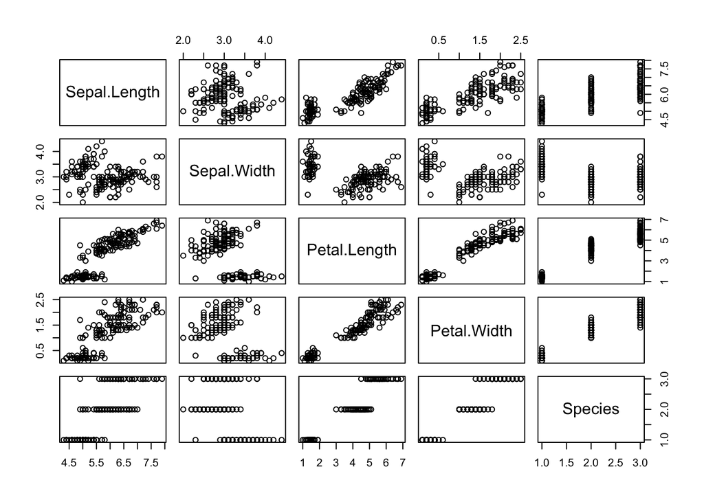

```r
plot(iris)
```

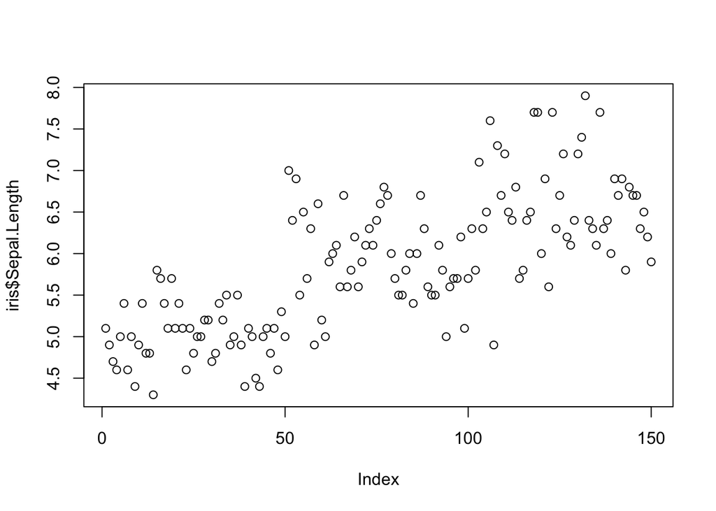

```r
plot(iris$Sepal.Length)
```

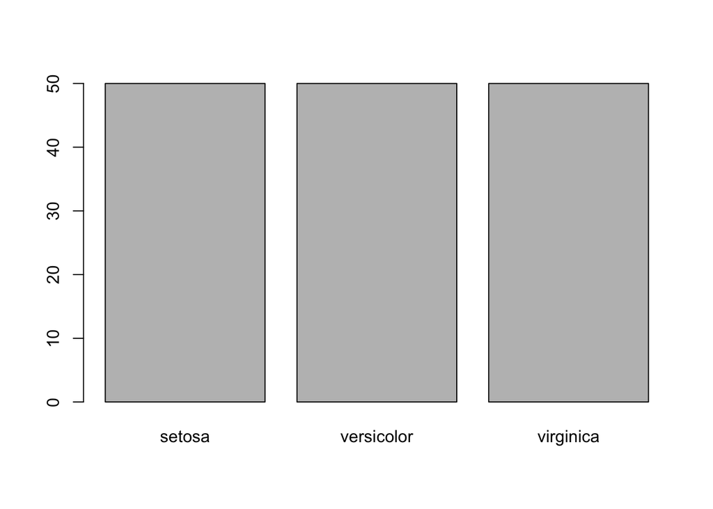

```r
plot(iris$Species)
```

plot()에서 포뮬러를 사용해 데이터를 그릴 수도 있다.

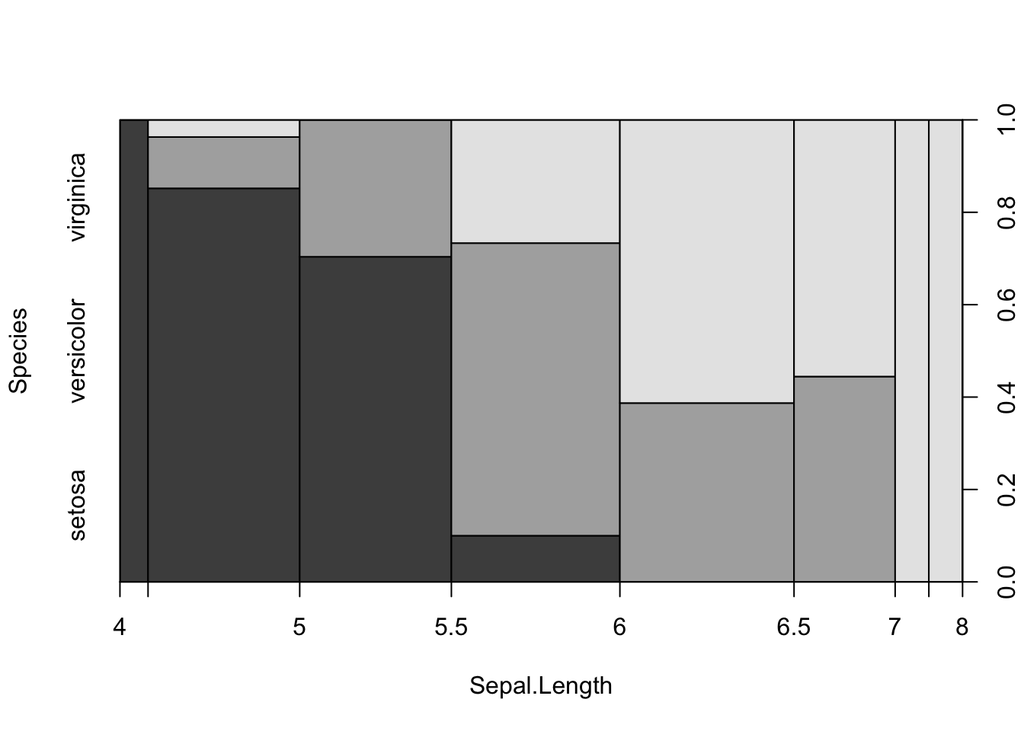

```r
plot(Species ~ Sepal.Length, data=iris)
```

다음 코드에서는 팩터 타입의 Species를 숫자로 변환해 점의 모양(pch)에 지정했다.

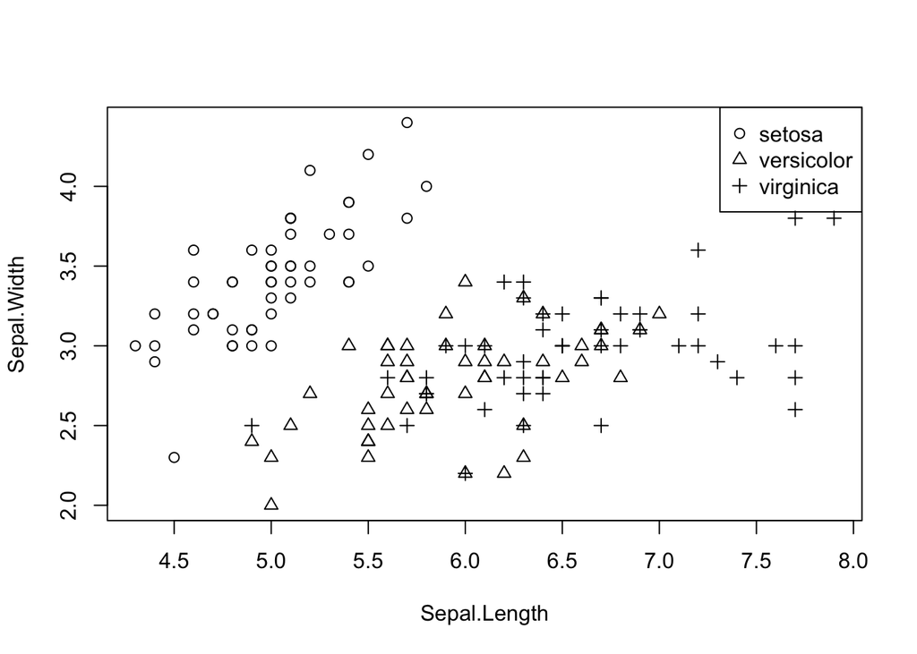

```r
with(iris, {
  plot(Sepal.Length, Sepal.Width, pch=as.numeric(Species))
  legend("topright", legend=levels(iris$Species), pch=1:3)
})
```

```r
library(caret)
```

```r
#에러 발생
#featurePlot(iris[, 1:4], iris$Species, "ellipse")
```

## 전처리

```r
# scale()은 행렬을 반환하므로 데이터 프레임으로 변환하고 cbind()로 Species를 합침
cbind(as.data.frame(scale(iris[1:4])), iris$Species)
```

```
##     Sepal.Length Sepal.Width Petal.Length   Petal.Width iris$Species
## 1    -0.89767388  1.01560199  -1.33575163 -1.3110521482       setosa
## 2    -1.13920048 -0.13153881  -1.33575163 -1.3110521482       setosa
## 3    -1.38072709  0.32731751  -1.39239929 -1.3110521482       setosa
## 4    -1.50149039  0.09788935  -1.27910398 -1.3110521482       setosa
## 5    -1.01843718  1.24503015  -1.33575163 -1.3110521482       setosa
## 6    -0.53538397  1.93331463  -1.16580868 -1.0486667950       setosa
## 7    -1.50149039  0.78617383  -1.33575163 -1.1798594716       setosa
## 8    -1.01843718  0.78617383  -1.27910398 -1.3110521482       setosa
## 9    -1.74301699 -0.36096697  -1.33575163 -1.3110521482       setosa
## 10   -1.13920048  0.09788935  -1.27910398 -1.4422448248       setosa
## 11   -0.53538397  1.47445831  -1.27910398 -1.3110521482       setosa
## 12   -1.25996379  0.78617383  -1.22245633 -1.3110521482       setosa
## 13   -1.25996379 -0.13153881  -1.33575163 -1.4422448248       setosa
## 14   -1.86378030 -0.13153881  -1.50569459 -1.4422448248       setosa
```

[output cut: 136 more lines]

#### 주성분 분석(PCA, Principal Component Analysis)

```r
x <- 1:10
y <- x + runif(10, min=-.5, max=.5)
z <- x + y + runif(10, min=-10, max=.10)
(data <- data.frame(x, y, z))
```

```
##     x        y          z
## 1   1 1.247892  0.4498958
## 2   2 1.999787  1.7068771
## 3   3 2.944499  0.3414733
## 4   4 3.917390  1.2477259
## 5   5 4.643420  5.6137577
## 6   6 6.460547 10.9622145
## 7   7 7.131579 13.2077568
## 8   8 8.301150 11.7805878
## 9   9 9.365475 17.7031666
## 10 10 9.899205 15.5478323
```

```r
# PCA 수행
pr <- princomp(data)
# 첫 번째와 두 번째 주성분에 의해 99.97%가 표현된다.
summary(pr)
```

```
## Importance of components:
##                           Comp.1     Comp.2       Comp.3
## Standard deviation     7.5120724 1.06782443 0.1339779563
## Proportion of Variance 0.9798887 0.01979962 0.0003116908
## Cumulative Proportion  0.9798887 0.99968831 1.0000000000
```

```r
# Comp.1, Comp.2 두 컬럼은 x, y, z를 2개 차원으로 축약한 결과다.
pr$scores[,1:2]
```

```
##           Comp.1     Comp.2
##  [1,]   9.596971  1.3630664
##  [2,]   7.874960  0.9691385
##  [3,]   8.299380 -0.9183679
##  [4,]   6.789882 -1.6173396
##  [5,]   2.445668 -0.3498549
##  [6,]  -3.147001  0.8497202
##  [7,]  -5.675029  1.0232370
##  [8,]  -5.284205 -1.0182771
##  [9,] -11.075384  0.8915482
## [10,]  -9.825244 -1.1928708
```

#### 원 핫 인코딩

랜덤 포레스트 알고리즘에서는 범주형 변수의 레벨수를 32개로 제한하고 있다. 이때 여러 개의 가변수를 사용해 범주형 변수를 재표현할 수 있으며 이를 원 핫 인코딩이라고 부른다.

```r
(x <- data.frame(lvl=factor(c("A", "B", "A", "A", "C")),
                 value=c(1,3,2,4,5)))
```

```
##   lvl value
## 1   A     1
## 2   B     3
## 3   A     2
## 4   A     4
## 5   C     5
```

```r
# A는 (0,0), B는 (1,0), C는 (0,1)로 변환
model.matrix(~ lvl, data=x)[,-1]
```

```
##   lvlB lvlC
## 1    0    0
## 2    1    0
## 3    0    0
## 4    0    0
## 5    0    1
```

### 결측치의 처리

```r
iris_na <- iris
iris_na[c(10, 20, 25, 40, 32), 3] <- NA
iris_na[c(33, 100, 123), 1] <- NA
# 결측치 존재 확인, 한 컬럼에 대해서만 조사할?때는 is.na() 사용
iris_na[!complete.cases(iris_na),]
```

```
##     Sepal.Length Sepal.Width Petal.Length Petal.Width    Species
## 10           4.9         3.1           NA         0.1     setosa
## 20           5.1         3.8           NA         0.3     setosa
## 25           4.8         3.4           NA         0.2     setosa
## 32           5.4         3.4           NA         0.4     setosa
## 33            NA         4.1          1.5         0.1     setosa
## 40           5.1         3.4           NA         0.2     setosa
## 100           NA         2.8          4.1         1.3 versicolor
## 123           NA         2.8          6.7         2.0  virginica
```

```r
# NA에 넣을 값 생성
mapply(median, iris_na[1:4], na.rm=TRUE)
```

```
## Sepal.Length  Sepal.Width Petal.Length  Petal.Width
##          5.8          3.0          4.4          1.3
```

```r
library(DMwR)
iris_na[!complete.cases(iris_na),]
```

```
##     Sepal.Length Sepal.Width Petal.Length Petal.Width    Species
## 10           4.9         3.1           NA         0.1     setosa
## 20           5.1         3.8           NA         0.3     setosa
## 25           4.8         3.4           NA         0.2     setosa
## 32           5.4         3.4           NA         0.4     setosa
## 33            NA         4.1          1.5         0.1     setosa
## 40           5.1         3.4           NA         0.2     setosa
## 100           NA         2.8          4.1         1.3 versicolor
## 123           NA         2.8          6.7         2.0  virginica
```

```r
# 중앙값으로 NA를 대치. knn값으로 NA를 대치하려면 knnImputation() 사용
centralImputation(iris_na[1:4])[c(10,20,25,32,33,40,100,123),]
```

```
##     Sepal.Length Sepal.Width Petal.Length Petal.Width
## 10           4.9         3.1          4.4         0.1
## 20           5.1         3.8          4.4         0.3
## 25           4.8         3.4          4.4         0.2
## 32           5.4         3.4          4.4         0.4
## 33           5.8         4.1          1.5         0.1
## 40           5.1         3.4          4.4         0.2
## 100          5.8         2.8          4.1         1.3
## 123          5.8         2.8          6.7         2.0
```

### 변수 선택

데이터의 변수 중 모델링에 가장 적합한 변수만 택하는 과정을 변수 선택 또는 피처 선택이라 한다.

#### 0에 가까운 분산(Near Zero Variance)

```r
library(caret)
library(mlbench)
data(Soybean)
# 데이터에서 분산이 0에 가까운 변수를 찾는다. (nzv가 TRUE)
nearZeroVar(Soybean, saveMetrics=TRUE)
```

```
##                  freqRatio percentUnique zeroVar   nzv
## Class             1.010989     2.7818448   FALSE FALSE
## date              1.137405     1.0248902   FALSE FALSE
## plant.stand       1.208191     0.2928258   FALSE FALSE
## precip            4.098214     0.4392387   FALSE FALSE
## temp              1.879397     0.4392387   FALSE FALSE
## hail              3.425197     0.2928258   FALSE FALSE
## crop.hist         1.004587     0.5856515   FALSE FALSE
## area.dam          1.213904     0.5856515   FALSE FALSE
## sever             1.651282     0.4392387   FALSE FALSE
## seed.tmt          1.373874     0.4392387   FALSE FALSE
## germ              1.103627     0.4392387   FALSE FALSE
## plant.growth      1.951327     0.2928258   FALSE FALSE
## leaves            7.870130     0.2928258   FALSE FALSE
## leaf.halo         1.547511     0.4392387   FALSE FALSE
## leaf.marg         1.615385     0.4392387   FALSE FALSE
## leaf.size         1.479638     0.4392387   FALSE FALSE
## leaf.shread       5.072917     0.2928258   FALSE FALSE
## leaf.malf        12.311111     0.2928258   FALSE FALSE
## leaf.mild        26.750000     0.4392387   FALSE  TRUE
## stem              1.253378     0.2928258   FALSE FALSE
## lodging          12.380952     0.2928258   FALSE FALSE
## stem.cankers      1.984293     0.5856515   FALSE FALSE
## canker.lesion     1.807910     0.5856515   FALSE FALSE
## fruiting.bodies   4.548077     0.2928258   FALSE FALSE
## ext.decay         3.681481     0.4392387   FALSE FALSE
## mycelium        106.500000     0.2928258   FALSE  TRUE
## int.discolor     13.204545     0.4392387   FALSE FALSE
## sclerotia        31.250000     0.2928258   FALSE  TRUE
## fruit.pods        3.130769     0.5856515   FALSE FALSE
## fruit.spots       3.450000     0.5856515   FALSE FALSE
## seed              4.139130     0.2928258   FALSE FALSE
## mold.growth       7.820896     0.2928258   FALSE FALSE
## seed.discolor     8.015625     0.2928258   FALSE FALSE
## seed.size         9.016949     0.2928258   FALSE FALSE
## shriveling       14.184211     0.2928258   FALSE FALSE
## roots             6.406977     0.4392387   FALSE FALSE
```

```r
nearZeroVar(Soybean)
```

```
## [1] 19 26 28
```

```r
mySoybean <- Soybean[,-nearZeroVar(Soybean)]
```

#### 상관 계수(Correlation)

상관 계수가 큰 예측 변수들이 있을 경우 모델의 성능이 떨어지거나 불안정해진다. 그래서 상관관계가 높은 변수들이 있으면 이들을 주성분 분석과 같은 방법을 사용해 서로 독립된 차원으로 변환하거나, 상관 계수가 큰 변수들을 제거해버린다.

```r
library(mlbench)
library(caret)
data(Vehicle)
# 3, 8, 11, 7, 9, 2번째 컬럼의 상관 계수가 높다.
findCorrelation(cor(subset(Vehicle, select=-c(Class))))
```

```
## [1]  3  8 11  7  9  2
```

```r
library(FSelector)
data(Ozone)
# V8, V12, V9 등이 V4와 상관 계수가 높다. 상관 계수로부터 변수의 중요도를 구한다.
(v <- linear.correlation(V4 ~., data=subset(Ozone, select=-c(V1, V2, V3))))
```

```
##     attr_importance
## V5       0.58414447
## V6       0.00468138
## V7       0.44356639
## V8       0.76986408
## V9       0.72317299
## V10      0.58026757
## V11      0.22990285
## V12      0.73194978
## V13      0.41471463
```

```r
# V4와 상관 계수값 이 큰 변수들을 찾는다.
cutoff.k(v, 3)
```

```
## [1] "V8"  "V12" "V9"
```

#### 카이 제곱 검정

```r
# 변수들의 중요도를 평가하고 그 중 세개의 변수를 선택한다.
(cs <- chi.squared(Class ~. , data=Vehicle))
```

```
##              attr_importance
## Comp               0.3043172
## Circ               0.2974762
## D.Circ             0.3587826
## Rad.Ra             0.3509038
## Pr.Axis.Ra         0.2264652
## Max.L.Ra           0.3234535
## Scat.Ra            0.4653985
## Elong              0.4556748
## Pr.Axis.Rect       0.4475087
## Max.L.Rect         0.3059760
## Sc.Var.Maxis       0.4338378
## Sc.Var.maxis       0.4921648
## Ra.Gyr             0.2940064
## Skew.Maxis         0.3087694
## Skew.maxis         0.2470216
## Kurt.maxis         0.3338930
## Kurt.Maxis         0.2732117
## Holl.Ra            0.3886266
```

```r
cutoff.k(cs, 3)
```

```
## [1] "Sc.Var.maxis" "Scat.Ra"      "Elong"
```

#### 모델을 사용한 변수 중요도 평가

```r
library(rpart)
data(BreastCancer)
m <- rpart(Class ~. , data=BreastCancer)
# 모델로부터 변수 중요도를 계산한다.
varImp(m)
```

```
##                  Overall
## Bare.nuclei     203.7284
## Bl.cromatin     197.9057
## Cell.shape      216.3834
## Cell.size       222.9401
## Id              307.8953
## Cl.thickness      0.0000
## Marg.adhesion     0.0000
## Epith.c.size      0.0000
## Normal.nucleoli   0.0000
## Mitoses           0.0000
```

### 모델 평가 방법

#### 평가 메트릭

분류 모델에서 모델 평가 메트릭은 모델에서 구한 예측값과 실제 값의 발생 빈도를 나열한 confusion matrix로부터 계산하다. True/False는 예측결과, Positive/Negative는 예측값

| — | Y | N |
| --- | --- | --- |
| Y | True Positive(TP) | False Positive(FP) |
| N | False Negative(FN) | True Negative(TN) |

- Precision: $\frac{TP}{TP+FP}$
- Accuracy: $\frac{TP+TN}{TP+FP+FN+TN}$
- Recall: $\frac{TP}{TP+FN}$

```r
predicted <- c(1,0,0,1,1,1,0,0,0,1,1,1)
actual <- c(1,0,0,1,1,0,1,1,0,1,1,1)
xtabs( ~ predicted + actual)
```

```
##          actual
## predicted 0 1
##         0 3 2
##         1 1 6
```

```r
# Accurary
sum(predicted == actual) / NROW(actual)
```

```
## [1] 0.75
```

```r
# one shot, one kill
# install.packages("e1071")
library(caret)
confusionMatrix(predicted, actual)
```

```
## Confusion Matrix and Statistics
##
##           Reference
## Prediction 0 1
##          0 3 2
##          1 1 6
##
##                Accuracy : 0.75
##                  95% CI : (0.4281, 0.9451)
##     No Information Rate : 0.6667
##     P-Value [Acc > NIR] : 0.3931
##
##                   Kappa : 0.4706
##  Mcnemar's Test P-Value : 1.0000
##
##             Sensitivity : 0.7500
##             Specificity : 0.7500
##          Pos Pred Value : 0.6000
##          Neg Pred Value : 0.8571
##              Prevalence : 0.3333
##          Detection Rate : 0.2500
##    Detection Prevalence : 0.4167
##       Balanced Accuracy : 0.7500
##
##        'Positive' Class : 0
##
```

No Information Rate: 가장 많은 값이 발견될 비율 (모델의 최소 성능 척도)

#### ROC 커브

많은 기계 학습 모델은 그 내부에서 결과가 Y일 확률 또는 점수를 계산한다. ROC 커브는 점수 기준을 달리할 때 TP Rate와 FP Rate가 어떻게 달라지는지 그래프로 표시한 것이다.(FP Rate 대비 TP Rate의 변화)

| 관측값 번호 | 점수 | 실제 분류 |
| --- | --- | --- |
| 3 | 0.937 | Y |
| 7 | 0.830 | Y |
| 2 | 0.738 | N |
| 15 | 0.720 | N |
| 6 | 0.603 | Y |

기준값 변화에 따른 TP Rate, FP Rate 의 변화

| 기준값 | TP Rate | FP Rate |
| --- | --- | --- |
| 0.937 | 1/3 | 0 |
| 0.830 | 2/3 | 0 |
| 0.738 | 2/3 | 1/2 |
| 0.720 | 2/3 | 2/2 |
| 0.603 | 3/3 | 2/2 |

ROC 커브를 그린 뒤 그 아래의 면적은 AUC(Area Under the Curve)라 하며 모델 간의 비교에 사용한다.

```r
set.seed(137)
# 분류 알고리즘이 예측한 점수
probs <- runif(100)
# 실제 분류가 저장된 벡터, 약간의 분류 실패 넣음
labels <- as.factor(ifelse(probs > .5 & runif(100) < .4, "A", "B"))
library(ROCR)
```

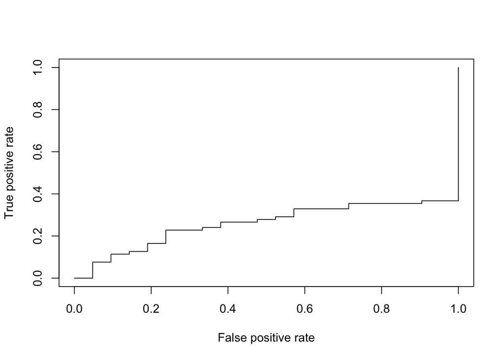

```r
pred <- prediction(probs, labels)
# TP Rate와 FP Rate 산출
plot(performance(pred, "tpr", "fpr"))
```

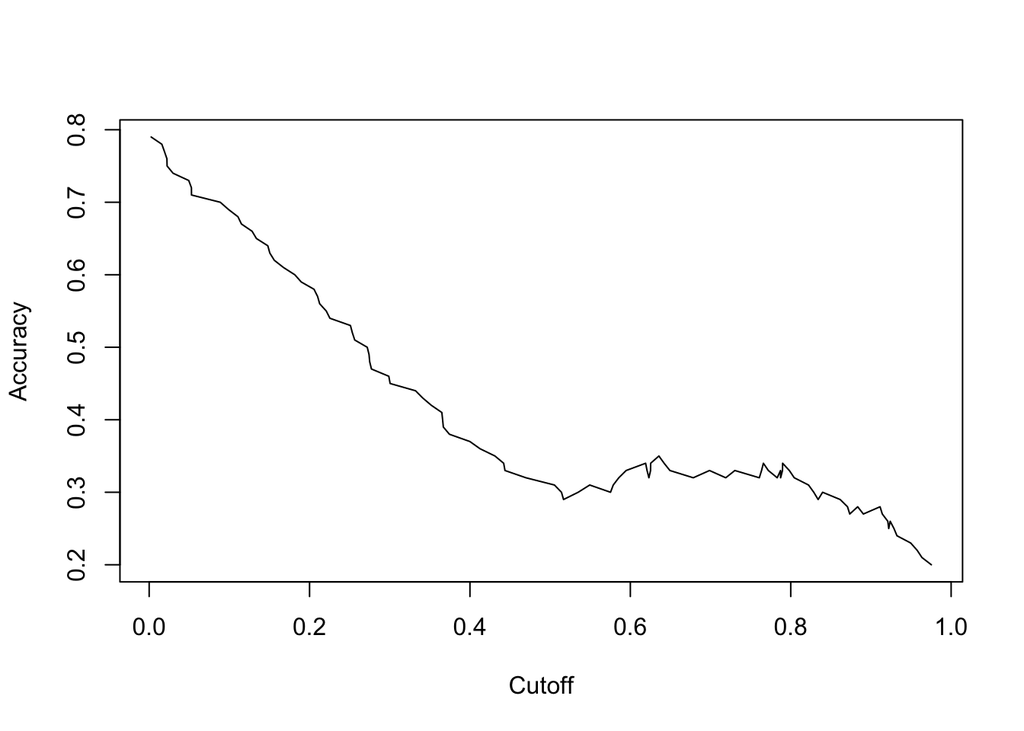

```r
# cutoff는 기준값
plot(performance(pred, "acc", "cutoff"))
```

```r
# auc는 0.2579867
performance(pred, "auc")
```

```
## An object of class "performance"
## Slot "x.name":
## [1] "None"
##
## Slot "y.name":
## [1] "Area under the ROC curve"
##
## Slot "alpha.name":
## [1] "none"
##
## Slot "x.values":
## list()
##
## Slot "y.values":
## [[1]]
## [1] 0.2579867
##
##
## Slot "alpha.values":
## list()
```

#### 교차 검증

교차 검증은 훈련 데이터와 테스트 데이터를 분리하여 모델을 만드는 방법 중 가장 자주 사용하는 기법으로, 데이터를 다수의 조각으로 나누어 훈련과 테스트를 반복하는 기법이다.

##### 과적합(Overfitting)

과적합은 주어진 데이터로부터 보장되는 것 이상으로 모델을 만들 때 발생한다.

#### 테스트 데이터

1. 데이터의 일부를 훈련 데이터, 나머지를 테스트 데이터로 분리한다.
2. 훈련 데이터로부터 모델을 만든다
- 만들어진 모델을 테스트 데이터에 대히 적용해 성능을 평가한다. 성능이 만족스럽지 않으면 2단계로 돌아간다- 전체 데이터로부터 모델을 만들고 이를 최종 모델로 정한다.